# Homework 1

#### Package/data Imports

```python
#Import packages
import numpy as np
import pandas as pd
import os
import matplotlib.pyplot as plt
import warnings

%matplotlib inline
warnings.filterwarnings('ignore')
```

```python
#Import data
url = 'https://raw.githubusercontent.com/PixarJunkie/dsc-478-programming-ml-apps/master/data/bank-data/bank_data.csv'
data = pd.read_csv(url)

#Numeric df
num_cols = data.select_dtypes(include = np.number)
#Non-numeric df
non_num_cols = data.select_dtypes(exclude = np.number)
non_num_cols.drop(columns = 'id', inplace = True)
```

## Problem 1:

Explore the general characteristics of the data as a whole: examine the means, standard deviations, and other statistics associated with the numerical attributes; show the distributions of values associated with categorical attributes; etc.

#### Numeric Summary Stats

##### Age

```python
#DF of notable stats
age_stats_df = pd.DataFrame({'Mode': [num_cols.age.mode()[0]], 'Mean': [round(num_cols.age.mean(), 2)], 'Stdev': [round(num_cols.age.std(), 2)], 'Median': [num_cols.age.median()], 'Min': [num_cols.age.min()], 'Max': [num_cols.age.max()]})
age_stats_df
```

|  | Mode | Mean | Stdev | Median | Min | Max |
| --- | --- | --- | --- | --- | --- | --- |
| 0 | 40 | 42.4 | 14.42 | 42.0 | 18 | 67 |

##### Income

```python
#DF of notable stats
income_stats_df = pd.DataFrame({'Mode': [num_cols.income.mode()[0]], 'Mean': [round(num_cols.income.mean(), 2)], 'Stdev': [round(num_cols.income.std(), 2)], 'Median': [num_cols.income.median()], 'Min': [num_cols.income.min()], 'Max': [num_cols.income.max()]})
income_stats_df
```

|  | Mode | Mean | Stdev | Median | Min | Max |
| --- | --- | --- | --- | --- | --- | --- |
| 0 | 38248.3 | 27524.03 | 12899.47 | 24925.3 | 5014.21 | 63130.1 |

##### Children

```python
#DF of notable stats
income_stats_df = pd.DataFrame({'Mode': [num_cols.children.mode()[0]], 'Mean': [round(num_cols.children.mean(), 2)], 'Stdev': [round(num_cols.children.std(), 2)], 'Median': [num_cols.children.median()], 'Min': [num_cols.children.min()], 'Max': [num_cols.children.max()]})
income_stats_df
```

|  | Mode | Mean | Stdev | Median | Min | Max |
| --- | --- | --- | --- | --- | --- | --- |
| 0 | 0 | 1.01 | 1.06 | 1.0 | 0 | 3 |

#### Categorical Histograms

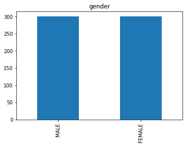

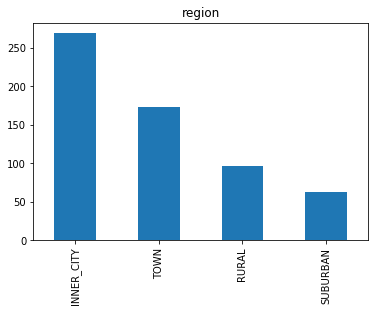

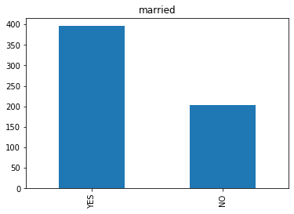

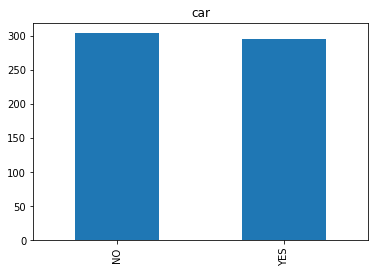

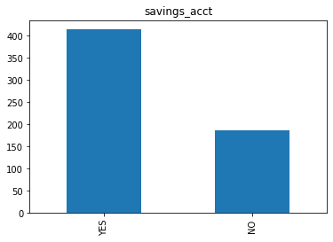

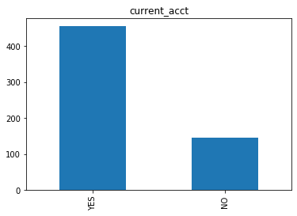

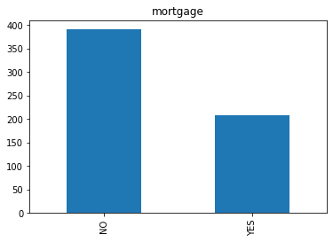

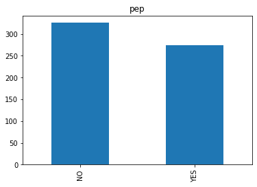

```python
#For each column (except id), plot histogram
for item, col in enumerate(non_num_cols.columns):
    non_num_cols[col].value_counts().plot(kind = 'bar')
    plt.title('%s' %(col))
    plt.show()
```

## Problem 2:

Suppose that the hypothetical bank is particularly interested in customers who buy the PEP (Personal Equity Plan) product. Compare and contrast the subsets of customers who buy and don't buy the PEP. Compute summaries (as in part 1) of the selected data with respect to all other attributes. Can you observe any significant differences between these segments of customers? Discuss your observations

```python
#Create dataframes for pep and non-pep
pep_df = data.loc[data.pep == 'YES']
#Drop id
pep_df.drop('id', axis = 1, inplace = True)
#Numeric dataframe
pep_num = pep_df.select_dtypes(include = np.number)

no_pep_df = data.loc[data.pep == 'NO']
#Drop id
no_pep_df.drop('id', axis = 1, inplace = True)
#Numeric dataframe
no_pep_num = no_pep_df.select_dtypes(include = np.number)
```

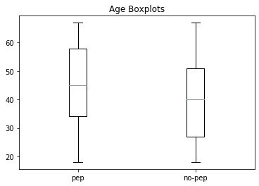

```python
#Age Box Plot
plot_ = plt.boxplot([pep_num.age, no_pep_df.age], labels = ['pep', 'no-pep'])
title_ = plt.title('Age Boxplots')
```

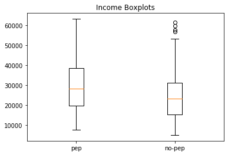

```python
#Income Box Plot
plot_ = plt.boxplot([pep_num.income, no_pep_df.income], labels = ['pep', 'no-pep'])
title_ = plt.title('Income Boxplots')
```

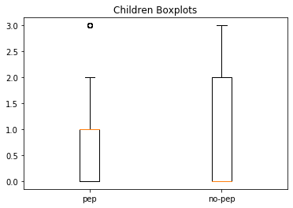

```python
#Children Box Plot
plot_ = plt.boxplot([pep_num.children, no_pep_df.children], labels = ['pep', 'no-pep'])
title_ = plt.title('Children Boxplots')
```

```python
#Mode dataframe
mode_df = pd.DataFrame({'pep-mode': [pep_df['%s' %(col)].mode()[0] for col in pep_df.columns], 'non-pep-mode': [no_pep_df['%s' %(col)].mode()[0] for col in no_pep_df.columns]}).set_index(pep_df.columns)
mode_df
```

|  | pep-mode | non-pep-mode |
| --- | --- | --- |
| age | 64 | 27 |
| income | 7756.36 | 38248.3 |
| children | 1 | 0 |
| gender | MALE | FEMALE |
| region | INNER_CITY | INNER_CITY |
| married | YES | YES |
| car | YES | NO |
| savings_acct | YES | YES |
| current_acct | YES | YES |
| mortgage | NO | NO |
| pep | YES | NO |

##### Findings:

The first thing I noticed was that there wasn't too much of an age gap between those with pep and those without. Both have regions with INNER_CITY as the mode and both pep and non-pep are more commonly married. Some of the differences I saw were in the most common number of children; 1 for pep and 0 for non-pep. Another difference is that non-pep people more commonly don't have cars while people with pep do. People with pep also have a higher salary range than non-pep people.

# Problem 3:

Use z-score normalization to standardize the values of the income attribute. Do not change the original income attribute in the table.

```python
#Create z_income column and apply stats.zscore
data_zscores = data.copy()
data_zscores['income_zscore'] = (data_zscores.income - data_zscores.income.mean())/data_zscores.income.std()
data_zscores.head()
```

|  | id | age | income | children | gender | region | married | car | savings_acct | current_acct | mortgage | pep | income_zscore |
| --- | --- | --- | --- | --- | --- | --- | --- | --- | --- | --- | --- | --- | --- |
| 0 | ID12101 | 48 | 17546.0 | 1 | FEMALE | INNER_CITY | NO | NO | NO | NO | NO | YES | -0.773523 |
| 1 | ID12102 | 40 | 30085.1 | 3 | MALE | TOWN | YES | YES | NO | YES | YES | NO | 0.198541 |
| 2 | ID12103 | 51 | 16575.4 | 0 | FEMALE | INNER_CITY | YES | YES | YES | YES | NO | NO | -0.848766 |
| 3 | ID12104 | 23 | 20375.4 | 3 | FEMALE | TOWN | YES | NO | NO | YES | NO | NO | -0.554180 |
| 4 | ID12105 | 57 | 50576.3 | 0 | FEMALE | RURAL | YES | NO | YES | NO | NO | NO | 1.787071 |

# Problem 4:

Discretize the age attribute into 3 categories (corresponding to "young", "mid-age", and "old"). [Do not change the original age attribute in the table.]

```python
#Create age_bin column and create age bins
data_age_bins = data.copy()
data_age_bins['age_bin'] = pd.qcut(data_age_bins.age, [0, .33, .66, 1], labels = ['young', 'middle-aged', 'old'])
data_age_bins.head()
```

|  | id | age | income | children | gender | region | married | car | savings_acct | current_acct | mortgage | pep | age_bin |
| --- | --- | --- | --- | --- | --- | --- | --- | --- | --- | --- | --- | --- | --- |
| 0 | ID12101 | 48 | 17546.0 | 1 | FEMALE | INNER_CITY | NO | NO | NO | NO | NO | YES | middle-aged |
| 1 | ID12102 | 40 | 30085.1 | 3 | MALE | TOWN | YES | YES | NO | YES | YES | NO | middle-aged |
| 2 | ID12103 | 51 | 16575.4 | 0 | FEMALE | INNER_CITY | YES | YES | YES | YES | NO | NO | old |
| 3 | ID12104 | 23 | 20375.4 | 3 | FEMALE | TOWN | YES | NO | NO | YES | NO | NO | young |
| 4 | ID12105 | 57 | 50576.3 | 0 | FEMALE | RURAL | YES | NO | YES | NO | NO | NO | old |

# Problem 5:

Use Min-Max Normalization to transform the values of all numeric attributes (income, age, children) in the original table (before the transforamtions in parts 3 and 4 above) onto the range 0.0-1.0.

```python
#Create numpy array for age, income, and children
data_min_max = data.copy()
data_min_max['income_minmax'] = (data_min_max.income - data_min_max.income.min())/(data_min_max.income.max() - data_min_max.income.min())
data_min_max['age_minmax'] = (data_min_max.age - data_min_max.age.min())/(data_min_max.age.max() - data_min_max.age.min())
data_min_max['children_minmax'] = (data_min_max.children - data_min_max.children.min())/(data_min_max.children.max() - data_min_max.children.min())
data_min_max.head()
```

|  | id | age | income | children | gender | region | married | car | savings_acct | current_acct | mortgage | pep | income_minmax | age_minmax | children_minmax |
| --- | --- | --- | --- | --- | --- | --- | --- | --- | --- | --- | --- | --- | --- | --- | --- |
| 0 | ID12101 | 48 | 17546.0 | 1 | FEMALE | INNER_CITY | NO | NO | NO | NO | NO | YES | 0.215634 | 0.612245 | 0.333333 |
| 1 | ID12102 | 40 | 30085.1 | 3 | MALE | TOWN | YES | YES | NO | YES | YES | NO | 0.431395 | 0.448980 | 1.000000 |
| 2 | ID12103 | 51 | 16575.4 | 0 | FEMALE | INNER_CITY | YES | YES | YES | YES | NO | NO | 0.198933 | 0.673469 | 0.000000 |
| 3 | ID12104 | 23 | 20375.4 | 3 | FEMALE | TOWN | YES | NO | NO | YES | NO | NO | 0.264320 | 0.102041 | 1.000000 |
| 4 | ID12105 | 57 | 50576.3 | 0 | FEMALE | RURAL | YES | NO | YES | NO | NO | NO | 0.783987 | 0.795918 | 0.000000 |

# Problem 6:

Convert the table (after normalization in part 5) into the standard spreadsheet format. Note that this requires converting each categorical attribute into multiple binary ("dummy") attributes (one for each values of the categorical attribute) and assigning binary values corresponding to the presence or not presence of the attribute value in the original record). The numeric attributes should remain unchanged. Save this new table into a file called bank_numeric.csv and submit it along with your assignment. Hint: you might consider using the get_dummies for Pandas data frames.

```python
#Path to save file
path = r'C:\Users\kbchi\Documents\School\dsc-478-programming-ml-apps\data\bank-data'

#Create transform dataframe and apply get_dummies to all non_numeric columns
data_num = pd.get_dummies(data_min_max, columns = non_num_cols.columns)
data_num.head()

#Write to csv
data_num.to_csv(os.path.join(path, 'bank_numeric.csv'), index = False)
```

# Problem 7:

Using the standardized data set (of the previous part), perform basic correlation analysis among the attributes. Discuss your results by indicating any significant positive or negative correlations among pairs of attributes. You need to construct a complete Correlation Matrix. Be sure to first remove the Customer ID column before creating the correlation matrix. Hint:you can create the correlation matrix by using the corr() function in Pandas or corrcoef function in NumPy.

```python
#Drop id column
data_num = data_num.drop('id', axis = 1)

#Correlation matirx
data_num.corr().style.background_gradient().set_precision(2)
```

|  | age | income | children | income_minmax | age_minmax | children_minmax | gender_FEMALE | gender_MALE | region_INNER_CITY | region_RURAL | region_SUBURBAN | region_TOWN | married_NO | married_YES | car_NO | car_YES | savings_acct_NO | savings_acct_YES | current_acct_NO | current_acct_YES | mortgage_NO | mortgage_YES | pep_NO | pep_YES |
| --- | --- | --- | --- | --- | --- | --- | --- | --- | --- | --- | --- | --- | --- | --- | --- | --- | --- | --- | --- | --- | --- | --- | --- | --- |
| age | 1 | 0.75 | 0.024 | 0.75 | 1 | 0.024 | 0.09 | -0.09 | -0.025 | 0.019 | 0.031 | -0.0085 | -0.01 | 0.01 | -0.078 | 0.078 | -0.18 | 0.18 | 0.035 | -0.035 | 0.016 | -0.016 | -0.17 | 0.17 |
| income | 0.75 | 1 | 0.037 | 1 | 0.75 | 0.037 | 0.024 | -0.024 | -0.048 | 0.085 | 0.03 | -0.036 | 0.0084 | -0.0084 | -0.082 | 0.082 | -0.27 | 0.27 | -0.032 | 0.032 | 0.015 | -0.015 | -0.22 | 0.22 |
| children | 0.024 | 0.037 | 1 | 0.037 | 0.024 | 1 | 0.014 | -0.014 | -0.051 | 0.09 | -0.014 | -0.007 | 0.049 | -0.049 | -0.036 | 0.036 | -0.042 | 0.042 | -0.0062 | 0.0062 | 0.074 | -0.074 | 0.058 | -0.058 |
| income_minmax | 0.75 | 1 | 0.037 | 1 | 0.75 | 0.037 | 0.024 | -0.024 | -0.048 | 0.085 | 0.03 | -0.036 | 0.0084 | -0.0084 | -0.082 | 0.082 | -0.27 | 0.27 | -0.032 | 0.032 | 0.015 | -0.015 | -0.22 | 0.22 |
| age_minmax | 1 | 0.75 | 0.024 | 0.75 | 1 | 0.024 | 0.09 | -0.09 | -0.025 | 0.019 | 0.031 | -0.0085 | -0.01 | 0.01 | -0.078 | 0.078 | -0.18 | 0.18 | 0.035 | -0.035 | 0.016 | -0.016 | -0.17 | 0.17 |
| children_minmax | 0.024 | 0.037 | 1 | 0.037 | 0.024 | 1 | 0.014 | -0.014 | -0.051 | 0.09 | -0.014 | -0.007 | 0.049 | -0.049 | -0.036 | 0.036 | -0.042 | 0.042 | -0.0062 | 0.0062 | 0.074 | -0.074 | 0.058 | -0.058 |
| gender_FEMALE | 0.09 | 0.024 | 0.014 | 0.024 | 0.09 | 0.014 | 1 | -1 | -0.023 | -0.0091 | -0.011 | 0.04 | 0.021 | -0.021 | 0.0067 | -0.0067 | 0.0072 | -0.0072 | -0.019 | 0.019 | 0.066 | -0.066 | 0.047 | -0.047 |
| gender_MALE | -0.09 | -0.024 | -0.014 | -0.024 | -0.09 | -0.014 | -1 | 1 | 0.023 | 0.0091 | 0.011 | -0.04 | -0.021 | 0.021 | -0.0067 | 0.0067 | -0.0072 | 0.0072 | 0.019 | -0.019 | -0.066 | 0.066 | -0.047 | 0.047 |
| region_INNER_CITY | -0.025 | -0.048 | -0.051 | -0.048 | -0.025 | -0.051 | -0.023 | 0.023 | 1 | -0.39 | -0.31 | -0.57 | -0.0033 | 0.0033 | 0.018 | -0.018 | 0.091 | -0.091 | -0.0079 | 0.0079 | -0.0021 | 0.0021 | -0.0011 | 0.0011 |
| region_RURAL | 0.019 | 0.085 | 0.09 | 0.085 | 0.019 | 0.09 | -0.0091 | 0.0091 | -0.39 | 1 | -0.15 | -0.28 | 0.023 | -0.023 | -0.024 | 0.024 | -0.037 | 0.037 | 0.0085 | -0.0085 | 0.052 | -0.052 | -0.02 | 0.02 |
| region_SUBURBAN | 0.031 | 0.03 | -0.014 | 0.03 | 0.031 | -0.014 | -0.011 | 0.011 | -0.31 | -0.15 | 1 | -0.22 | -0.012 | 0.012 | 0.061 | -0.061 | -0.0026 | 0.0026 | -0.038 | 0.038 | -0.0046 | 0.0046 | -0.063 | 0.063 |
| region_TOWN | -0.0085 | -0.036 | -0.007 | -0.036 | -0.0085 | -0.007 | 0.04 | -0.04 | -0.57 | -0.28 | -0.22 | 1 | -0.0064 | 0.0064 | -0.042 | 0.042 | -0.069 | 0.069 | 0.027 | -0.027 | -0.037 | 0.037 | 0.059 | -0.059 |
| married_NO | -0.01 | 0.0084 | 0.049 | 0.0084 | -0.01 | 0.049 | 0.021 | -0.021 | -0.0033 | 0.023 | -0.012 | -0.0064 | 1 | -1 | -0.0096 | 0.0096 | 0.029 | -0.029 | -0.06 | 0.06 | -0.022 | 0.022 | -0.19 | 0.19 |
| married_YES | 0.01 | -0.0084 | -0.049 | -0.0084 | 0.01 | -0.049 | -0.021 | 0.021 | 0.0033 | -0.023 | 0.012 | 0.0064 | -1 | 1 | 0.0096 | -0.0096 | -0.029 | 0.029 | 0.06 | -0.06 | 0.022 | -0.022 | 0.19 | -0.19 |
| car_NO | -0.078 | -0.082 | -0.036 | -0.082 | -0.078 | -0.036 | 0.0067 | -0.0067 | 0.018 | -0.024 | 0.061 | -0.042 | -0.0096 | 0.0096 | 1 | -1 | 0.034 | -0.034 | -0.035 | 0.035 | -0.0077 | 0.0077 | 0.019 | -0.019 |
| car_YES | 0.078 | 0.082 | 0.036 | 0.082 | 0.078 | 0.036 | -0.0067 | 0.0067 | -0.018 | 0.024 | -0.061 | 0.042 | 0.0096 | -0.0096 | -1 | 1 | -0.034 | 0.034 | 0.035 | -0.035 | 0.0077 | -0.0077 | -0.019 | 0.019 |
| savings_acct_NO | -0.18 | -0.27 | -0.042 | -0.27 | -0.18 | -0.042 | 0.0072 | -0.0072 | 0.091 | -0.037 | -0.0026 | -0.069 | 0.029 | -0.029 | 0.034 | -0.034 | 1 | -1 | 0.043 | -0.043 | -0.0016 | 0.0016 | -0.073 | 0.073 |
| savings_acct_YES | 0.18 | 0.27 | 0.042 | 0.27 | 0.18 | 0.042 | -0.0072 | 0.0072 | -0.091 | 0.037 | 0.0026 | 0.069 | -0.029 | 0.029 | -0.034 | 0.034 | -1 | 1 | -0.043 | 0.043 | 0.0016 | -0.0016 | 0.073 | -0.073 |
| current_acct_NO | 0.035 | -0.032 | -0.0062 | -0.032 | 0.035 | -0.0062 | -0.019 | 0.019 | -0.0079 | 0.0085 | -0.038 | 0.027 | -0.06 | 0.06 | -0.035 | 0.035 | 0.043 | -0.043 | 1 | -1 | -0.037 | 0.037 | 0.025 | -0.025 |
| current_acct_YES | -0.035 | 0.032 | 0.0062 | 0.032 | -0.035 | 0.0062 | 0.019 | -0.019 | 0.0079 | -0.0085 | 0.038 | -0.027 | 0.06 | -0.06 | 0.035 | -0.035 | -0.043 | 0.043 | -1 | 1 | 0.037 | -0.037 | -0.025 | 0.025 |
| mortgage_NO | 0.016 | 0.015 | 0.074 | 0.015 | 0.016 | 0.074 | 0.066 | -0.066 | -0.0021 | 0.052 | -0.0046 | -0.037 | -0.022 | 0.022 | -0.0077 | 0.0077 | -0.0016 | 0.0016 | -0.037 | 0.037 | 1 | -1 | -0.024 | 0.024 |
| mortgage_YES | -0.016 | -0.015 | -0.074 | -0.015 | -0.016 | -0.074 | -0.066 | 0.066 | 0.0021 | -0.052 | 0.0046 | 0.037 | 0.022 | -0.022 | 0.0077 | -0.0077 | 0.0016 | -0.0016 | 0.037 | -0.037 | -1 | 1 | 0.024 | -0.024 |
| pep_NO | -0.17 | -0.22 | 0.058 | -0.22 | -0.17 | 0.058 | 0.047 | -0.047 | -0.0011 | -0.02 | -0.063 | 0.059 | -0.19 | 0.19 | 0.019 | -0.019 | -0.073 | 0.073 | 0.025 | -0.025 | -0.024 | 0.024 | 1 | -1 |
| pep_YES | 0.17 | 0.22 | -0.058 | 0.22 | 0.17 | -0.058 | -0.047 | 0.047 | 0.0011 | 0.02 | 0.063 | -0.059 | 0.19 | -0.19 | -0.019 | 0.019 | 0.073 | -0.073 | -0.025 | 0.025 | 0.024 | -0.024 | -1 | 1 |

# Problem 8:

Using Matplotlib library and/or ploting capabilities of Pandas, create a scatter plot of the (non-normalized) Income attribute relative to Age. Be sure that your plot contains appropriate labels for the axes. Do these variables seem correlated?

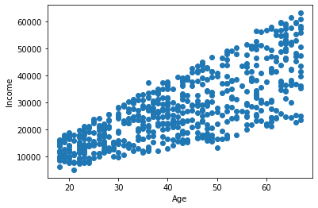

```python
#Plot of age vs. income
plot_ = plt.scatter(data.age, data.income)
plot_x = plt.xlabel('Age')
plot_y = plt.ylabel('Income')
```

##### Conclusion:

There is a noticeable correlation between age and income. From the correlation plot from problem 7 we can see that the correlation between age and income is 0.75.

# Problem 9:

Create histograms for (non-normalized) Income (using 9 bins) and Age (using 15 bins).

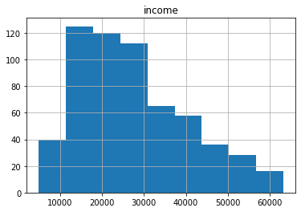

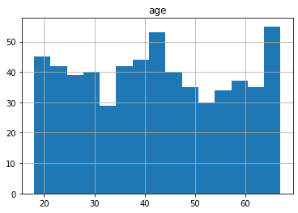

```python
income_ = data.hist('income', bins = 9)
age_ = data.hist('age', bins = 15)
```

# Problem 10:

Using a bar graph, plot the distribution of the values of the region attribute.

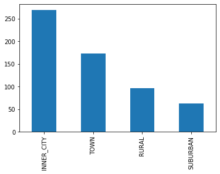

```python
data.region.value_counts().plot(kind = 'bar')
```

# Problem 11:

Perform a cross-tabulation of the region attribute with the pep attribute. This requires the aggregation of the occurrences of each pep value (yes or no) separately for each value of the region attribute. Show the results as a 4 by 2 (region x pep) table with entries representing the counts. Hint: you can either use Numpy or use aggregations functions in Pandas such as groupby() and cross-tab(). Then, either using Matplotlib directly or the plot() function in Pandas create a bar chart graph to visualize of the relationships between these sets of variables. Hint: This example of creating simple bar charts using Matplotlib may be useful.

```python
#Group by region and pep
grouped_df = data.groupby(['region', 'pep']).size().reset_index()
grouped_df.rename(columns = {0: 'count'})
```

|  | region | pep | count |
| --- | --- | --- | --- |
| 0 | INNER_CITY | NO | 146 |
| 1 | INNER_CITY | YES | 123 |
| 2 | RURAL | NO | 50 |
| 3 | RURAL | YES | 46 |
| 4 | SUBURBAN | NO | 28 |
| 5 | SUBURBAN | YES | 34 |
| 6 | TOWN | NO | 102 |
| 7 | TOWN | YES | 71 |

```python
#Group by region (only way I could see how to get a 4x2)
grouped_df = data.groupby(['region']).size().reset_index()
grouped_df.rename(columns = {0: 'count'})
```

|  | region | count |
| --- | --- | --- |
| 0 | INNER_CITY | 269 |
| 1 | RURAL | 96 |
| 2 | SUBURBAN | 62 |
| 3 | TOWN | 173 |

Having trouble seeing how to add pep to the groupby withough increasing the number of rows since pep has 2 levels for each region.

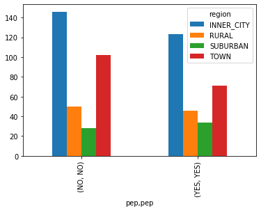

```python
#Bar Plot of region x pep
data.groupby(['region', 'pep']).pep.value_counts().unstack(0).plot(kind = 'bar')
```